# Bivariate analysis of numerical vs categorical columns using Penguins dataset

```python
import pandas as pd
import seaborn as sns
```

```python
penguins = sns.load_dataset("penguins")
sns.set_style("dark")
```

```python
penguins.head()
```

|  | species | island | bill_length_mm | bill_depth_mm | flipper_length_mm | body_mass_g | sex |
| --- | --- | --- | --- | --- | --- | --- | --- |
| 0 | Adelie | Torgersen | 39.1 | 18.7 | 181.0 | 3750.0 | Male |
| 1 | Adelie | Torgersen | 39.5 | 17.4 | 186.0 | 3800.0 | Female |
| 2 | Adelie | Torgersen | 40.3 | 18.0 | 195.0 | 3250.0 | Female |
| 3 | Adelie | Torgersen | NaN | NaN | NaN | NaN | NaN |
| 4 | Adelie | Torgersen | 36.7 | 19.3 | 193.0 | 3450.0 | Female |

```python
penguins.groupby(by="species").mean()
```

| species | bill_length_mm | bill_depth_mm | flipper_length_mm | body_mass_g |
| --- | --- | --- | --- | --- |
| Adelie | 38.791391 | 18.346358 | 189.953642 | 3700.662252 |
| Chinstrap | 48.833824 | 18.420588 | 195.823529 | 3733.088235 |
| Gentoo | 47.504878 | 14.982114 | 217.186992 | 5076.016260 |

I chose to compare species and island to each of the numerical columns

# Species

It seems there are less differences between Adelie and Chinstrap than between Adelie, Chinstrap and Gentoo.

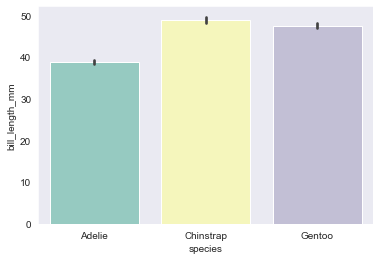

```python
sns.barplot(y="bill_length_mm",x="species",data=penguins)
```

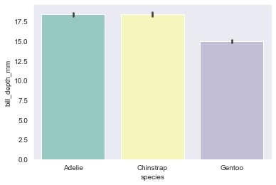

```python
sns.barplot(y="bill_depth_mm",x="species",data=penguins)
```

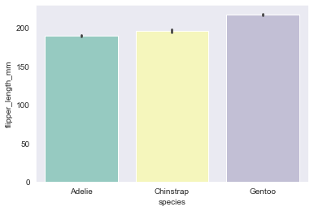

```python
sns.barplot(y="flipper_length_mm",x="species",data=penguins)
```

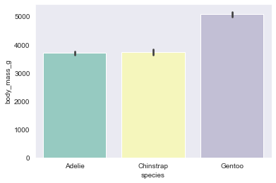

```python
sns.barplot(y="body_mass_g",x="species",data=penguins)
```

# Island

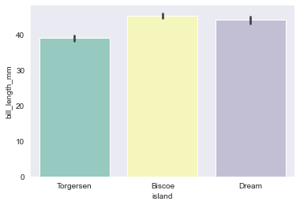

```python
sns.barplot(y="bill_length_mm",x="island",data=penguins)
```

There is no statistically significant difference between Biscoe and Dream, but there is between Togersen and the others

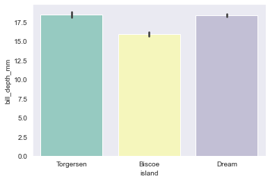

```python
sns.barplot(y="bill_depth_mm",x="island",data=penguins)
```

There is no statistically significant difference between Togersen and Dream, but there is between Biscoe and the others

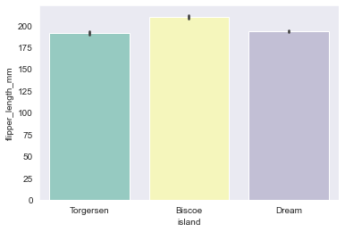

```python
sns.barplot(y="flipper_length_mm",x="island",data=penguins)
```

There is no statistically significant difference between Togersen and Dream, but there is between Biscoe and the others

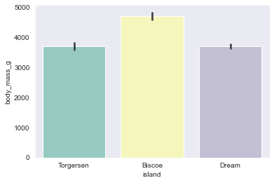

```python
sns.barplot(y="body_mass_g",x="island",data=penguins)
```

There is no statistically significant difference between Togersen and Dream, but there is between Biscoe and the others